# Introduction to 21019 homework

## HW2

### 题5.4

Write a function to compute a Monte Carlo estimate of the $Beta(3, 3)$ cdf, and use the function to estimate $F(x)$ for$x = 0.1, 0.2, \cdots, 0.9.$Compare the estimates with the values returned by the pbeta function in R.

概率密度函数为:
$$f(x;\alpha,\beta)=\frac{1}{B(\alpha,\beta)}x^{\alpha-1}(1-x)^{\beta-1}$$

累计分布函数为:
$$\begin{aligned}
F(x;\alpha,\beta)=&\frac{1}{B(\alpha,\beta)}\int_0^xt^{\alpha-1}(1-t)^{\beta-1}dt\\
=&\frac{x}{B(\alpha,\beta)}E[t^{\alpha-1}(1-t)^{\beta-1}],t\sim U(0,x)
\end{aligned}$$

```r
beta_mc<-function(m=1e5,x)
{
  ###m为生成均匀分布样本数,默认取1e5
  ###x取值范围为0,1
  ###输出蒙特卡洛方法得到的B(x;3,3)
  if(x<0 || x>1)
    stop("x is out of range")
  t<-runif(m,min=0,max=x)
  theta.hat<-x*mean(t^2*(1-t)^2)/beta(3,3)
  return(theta.hat)
}
```

```r
set.seed(0)
x<-seq(0.1,0.9,0.1)
n<-length(x)
theta.hat<-theta<-numeric(n)
for(i in 1:n)
{
  theta.hat[i]=beta_mc(x=x[i])
  theta[i]=pbeta(q=x[i],shape1 = 3,shape2 = 3)
  print(paste0("x=",x[i],"时,生成值:", round(theta.hat[i],3),",理论值:", round(theta[i],3)))
}
```

```
## [1] "x=0.1时,生成值:0.009,理论值:0.009"
## [1] "x=0.2时,生成值:0.058,理论值:0.058"
## [1] "x=0.3时,生成值:0.163,理论值:0.163"
## [1] "x=0.4时,生成值:0.317,理论值:0.317"
## [1] "x=0.5时,生成值:0.499,理论值:0.5"
## [1] "x=0.6时,生成值:0.683,理论值:0.683"
## [1] "x=0.7时,生成值:0.837,理论值:0.837"
## [1] "x=0.8时,生成值:0.942,理论值:0.942"
## [1] "x=0.9时,生成值:0.995,理论值:0.991"
```

### 题5.9

The Rayleigh density [156, (18.76)] is
$$f(x)=\frac{x}{\sigma^2}e^{-x^2/(2\sigma^2)},\qquad x\geq0,\sigma>0.$$
Implement a function to generate samples from a $Rayleigh(\sigma)$ distribution, using antithetic variables. What is the percent reduction in variance of $\frac{X+X'}{2}$ compared with $\frac{X_1+X_2}{2}$ for independent$X_1,X_2$?

分布函数

$$\begin{aligned}
F_X(x)=&\int_{0}^xf(y)dy\\
=&\int_{0}^x\frac{y}{\sigma^2}e^{-y^2/(2\sigma^2)}dy\\
=&1-e^{-x^2/(2\sigma^2)}
\end{aligned}$$

对偶变量估计量为:
$$\hat{\theta}'=\frac{1}{m}\sum_{j=1}^{m/2}(x\frac{U_j}{\sigma^2}e^{-U_j^2/(2\sigma^2)}+x\frac{x-U_j}{\sigma^2}e^{-(x-U_j)^2/(2\sigma^2)}),U_j\sim U(0,x).$$

```r
Rayleigh<-function(sigma, n=10000, antithetic=TRUE)
{
 u <- runif(n)#生成n/2个均匀随机数
  if(!antithetic) v <- runif(n) else
    v <- 1-u#若应用对偶变量，则令后一半均匀随机数v为1-u，否则v为n个均匀随机数且与u独立
  X1 <- sqrt(-2*sigma^2*log(u))#利用u生成一组Rayleigh分布随机数X1
  X2 <- sqrt(-2*sigma^2*log(v))#利用v生成一组Rayleigh分布随机数X2
  X <- (X1+X2)/2#取两组样本均值得到最终估计
}
```

```r
set.seed(0)
sigma<-1:5
var_reduction <- matrix(nrow = 1, ncol = length(sigma))#存储结果矩阵
for (i in 1:length(sigma)) {
  simple<-Rayleigh(sigma = sigma[i],antithetic=FALSE)
  antithetic<-Rayleigh(sigma = sigma[i])
  var_reduction[1, i] <- (var(simple)-var(antithetic))/var(simple)
}
dimnames(var_reduction)[[2]] <- paste("sigma =", sigma)#重命名各列
knitr::kable(var_reduction, caption = "表2.1：对偶变量法生成Rayleigh随机数相比简单方法生成Rayleigh随机数方差减少的比例")#绘制结果表格
```

表2.1：对偶变量法生成Rayleigh随机数相比简单方法生成Rayleigh随机数方差减少的比例

| sigma = 1 | sigma = 2 | sigma = 3 | sigma = 4 | sigma = 5 |
| --- | --- | --- | --- | --- |
| 0.9494173 | 0.9420766 | 0.9475476 | 0.9506812 | 0.9445254 |

### 题5.13

Find two importance functions$f_1$ and $f_2$ that are supported on $(1,+\infty)$ and are ‘close’ to
$$g(x)=\frac{x^2}{\sqrt{2\pi}}e^{-x^2/2},\qquad x>1$$
Which of your two importance functions should produce the smaller variance in estimating
$$\int_1^{+\infty}\frac{x^2}{\sqrt{2\pi}}e^{-x^2/2}dx$$
by importance sampling? Explain.

选取函数$f_1(x),f_2(x)$如下,$f_1$理应产生更小方差，因为与$g(x)$更接近

$$\begin{aligned}
&f_1(x)=1\\
&f_2(x)=\frac{e^{-x}}{1-e^{-1}}
\end{aligned}$$

$$\begin{aligned}
&\because\int_0^{+\infty}\frac{x^2}{\sqrt{2\pi}}e^{-x^2/2}dx=\frac{1}{2} \\
&\therefore \int_1^{+\infty}\frac{x^2}{\sqrt{2\pi}}e^{-x^2/2}dx=\frac{1}{2}-\int_0^{1}\frac{x^2}{\sqrt{2\pi}}e^{-x^2/2}dx
\end{aligned}$$

```r
g<-function(x) exp(-x^2/2)*x^2/sqrt(2*pi)
f1<-function(x) rep(1,length(x))
f2<-function(x) exp(-x)/(1-exp(-1))

gs <- c(expression(g(x)==x^2*e^{-x^2/2}/sqrt(2*pi)),
            expression(f[1](x)==1),
            expression(f[2](x)==e^{-x}/(1-e^{-1})))
#计算(0,1)内理论积分值
I_g<-integrate(g,0,1)
I_g
```

```
## 0.09937402 with absolute error < 1.1e-15
```

```r
#计算理论积分值
1/2-I_g$value
```

```
## [1] 0.400626
```

[figure not shown]

```r
x <- seq(0, 1, .01)
plot(x,g(x),col=1,ylim=c(0,3),lty=1,type = "l")
lines(x,f1(x),col=2,lty=2)
lines(x,f2(x),col=3,lty=3)
legend("topleft", legend = gs,
           lty = 1:3, inset = 0.02,col=1:3)
```

### 题5.14

Obtain a Monte Carlo estimate of
$$\int_1^{+\infty}\frac{x^2}{\sqrt{2\pi}}e^{-x^2/2}dx$$

by importance sampling.

```r
set.seed(0)
  m <- 10000
  est <- sd <- numeric(2)

 x <- runif(m) #using f1
  fg <- g(x)
  est[1] <- mean(fg)
  sd[1] <- sd(fg)
u <- runif(m) #f2, inverse transform method
  x <- - log(1 - u * (1 - exp(-1)))
  fg <- g(x) / (exp(-x) / (1 - exp(-1)))
  est[2] <- mean(fg)
  sd[2] <- sd(fg)
```

```r
  res <- rbind(est=round(1/2-est,3), sd=round(sd,3))
  print(res)
```

```
##      [,1]  [,2]
## est 0.400 0.400
## sd  0.079 0.113
```

可以看出,$f_1(x)$的方差更小

## HW3

### 题6.5

Suppose a 95% symmetric t-interval is applied to estimate a mean, but the sample data are non-normal. Then the probability that the confidence interval covers the mean is not necessarily equal to 0.95. Use a Monte Carlo experiment to estimate the coverage probability of the t-interval for random samples of $\chi^2(2)$ data with sample size $n = 20$. Compare your t-interval results with the simulation results in Example 6.4. (The t-interval should be more robust to departures from normality than the interval for variance.)

假设理论上样本$X\sim N(2,\sigma^2),\sigma^2=4$

$$\frac{\bar{x}-\mu}{S_n/\sqrt{n}}\sim t_{n-1}$$

置信区间为
$$[\mu-t_{n-1}(1-\alpha/2)S_n/\sqrt{n-1},\mu+t_{n-1}(1-\alpha/2)S_n/\sqrt{n}]$$
而实际生成的样本为$X\sim \chi^2(2),E(X)=2,Var(X)=4$

```r
set.seed(13)
n<-20
alpha<-0.05
m<-1e4
p<-numeric(m)

for(i in 1:m){
 x<-rchisq(n,2)
if(abs(mean(x)-2)<=sd(x)/sqrt(n)*qt(1-alpha/2,df=n-1)) p[i]=1
}
mean(p)
```

```
## [1] 0.916
```

使用Example 6.4中的模拟

```r
set.seed(123)
n<-20
alpha<-0.05
m<-1e4
UCL<-numeric(m)
#x<-rchisq(n,2)
for(i in 1:m){
 x<-rchisq(n,2)
UCL[i]<-(n-1)*var(x)/qchisq(alpha,df=n-1)

}
mean((UCL>4))
```

```
## [1] 0.7881
```

对比可得，t区间更加稳健

### 题6.A

Use Monte Carlo simulation to investigate whether the empirical Type I error rate of the t-test is approximately equal to the nominal significance level $\alpha$, when the sampled population is non-normal. The t-test is robust to mild departures from normality. Discuss the simulation results for the cases where the sampled population is (i)$\chi^2(1)$, (ii) Uniform(0,2), and (iii) Exponential(rate=1). In each case, test $H_0:\mu=\mu_0$vs$H_a:\mu\neq\mu_0$, where$\mu_0$ is the mean of$\chi^2(1)$, Uniform(0,2), and Exponential(1), respectively.

```r
set.seed(0)
n<-100
m<-1e4
p.val1<-p.val2<-p.val3<-numeric(m)
alpha<-.05
mu<-1
for(i in 1:m)
{
p.val1[i]<-t.test(rchisq(n,df=1),mu=mu,alternative = "two.sided")$p.value
p.val2[i]<-t.test(runif(n,min=0,max=2),mu=mu,alternative = "two.sided")$p.value
p.val3[i]<-t.test(rexp(n),mu=mu,alternative = "two.sided")$p.value
}
##可以看出一型错误率都较小，接近0.05，说明t分布足够稳健
print(round(c(mean(p.val1<=alpha),
mean(p.val2<=alpha),
mean(p.val3<=alpha)),3))
```

```
## [1] 0.068 0.049 0.062
```

### EXERCISE

If we obtain the powers for two methods under a particular simulation setting with 10,000 experiments: say, 0.651 for one method and 0.676 for another method. We want to know if the powers are different at 0.05 level.

(1)What is the corresponding hypothesis test problem?

(2)What test should we use? Z-test, two-sample t-test, paired-t test or McNemar test? Why?

(3)Please provide the least necessary information for hypothesis testing

$$H_0:\pi(\theta_1)=\pi'(\theta_1),\theta\sim \Theta_1,\leftrightarrow H_a:\pi(\theta_1)\neq\pi'(\theta_1),\theta\sim \Theta_1$$

(2)McNemar test. Because it is equivalent to test whether the acceptance rates of the two methods are the same. Also, a contingency table can be naturally constructed as in 3.

```r
mat <-
  matrix(c(6510, 3490, 10000, 6760, 3240, 10000, 13270, 6730, 20000), 3, 3,
         dimnames = list(
           c("Rejected", "Accepted", "total"),
           c("method A", "method B", "total")
         ))
mat
```

```
##          method A method B total
## Rejected     6510     6760 13270
## Accepted     3490     3240  6730
## total       10000    10000 20000
```

The test statistic:
$$\chi^2 = \sum_{i,j=1}^2 \frac{(n_{ij}-n_{i+} n_{+j}/n)^2}{n_{i+}n_{+j}/n} \rightarrow \chi^2_1.$$
Note that $\chi^2 = 13.9966$ and the p-value is $P(\chi^2_1 > \chi^2) = 0.0001831415 < 0.05$. Therefore, we reject the null hypothesis $H_0$, that is, the powers are different at $0.05$ level.

## HW4

### 题6.C

Repeat Examples 6.8 and 6.10 for Mardia’s multivariate skewness test. Mardia [187] proposed tests of multivariate normality based on multivariate generalizations of skewness and kurtosis. If X and Y are iid, the multivariate population skewness $\beta_{1,d}$ is defined by Mardia as
$$\beta_{1,d}=E[(X-\mu)^T\Sigma^{-1}(Y-\mu)]^3.$$

Under normality,$\beta_{1,d}.$ The multivariate skewness statistic is
$$b_{1,d}=\frac{1}{n^2}\sum_{i,j=1}^n((X_i-\bar{x})^T\hat{\Sigma}^{-1}(X_j-\bar{X}))^3,$$
where $\hat{\Sigma}$ is the maximum likelihood estimator of covariance. Large values of ˆ $b_{1,d}$ are significant. The asymptotic distribution of $nb_{1,d}/6$ is chisquared with $d(d + 1)(d + 2)/6$ degrees of freedom.

#### Example 6.8

```r
n <- c(10, 20, 30, 50, 100, 500) #sample sizes
cv <- qnorm(.975, 0, sqrt(6/n)) #crit. values for each n
sk <- function(x) {
#computes the sample skewness coeff.
xbar <- mean(x)
m3 <- mean((x - xbar)^3)
m2 <- mean((x - xbar)^2)
return( m3 / m2^1.5 )
}
```

```r
set.seed(1234)
#n is a vector of sample sizes
#we are doing length(n) different simulations
p.reject <- numeric(length(n)) #to store sim. results
m <- 10000 #num. repl. each sim.
for (i in 1:length(n)) {
sktests <- numeric(m) #test decisions
for (j in 1:m) {
x <- rnorm(n[i])
#test decision is 1 (reject) or 0
sktests[j] <- as.integer(abs(sk(x)) >= cv[i] )
}
p.reject[i] <- mean(sktests) #proportion rejected
}
p.reject
```

```
## [1] 0.0132 0.0299 0.0342 0.0377 0.0423 0.0501
```

```r
cv <- qnorm(.975, 0, sqrt(6*(n-2) / ((n+1)*(n+3))))
round(cv, 4)
```

```
## [1] 1.1355 0.9268 0.7943 0.6398 0.4660 0.2134
```

```r
#n is a vector of sample sizes
#we are doing length(n) different simulations
p.reject <- numeric(length(n)) #to store sim. results
m <- 2500 #num. repl. each sim.
for (i in 1:length(n)) {
sktests <- numeric(m) #test decisions
for (j in 1:m) {
x <- rnorm(n[i])
#test decision is 1 (reject) or 0
sktests[j] <- as.integer(abs(sk(x)) >= cv[i] )
}
p.reject[i] <- mean(sktests) #proportion rejected
}
p.reject
```

```
## [1] 0.0472 0.0564 0.0504 0.0544 0.0516 0.0524
```

#### Example 6.10

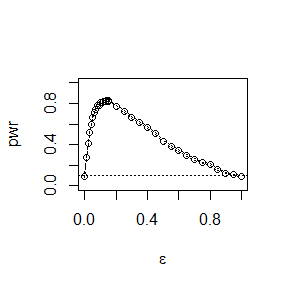

```r
alpha <- .1
n <- 30
m <- 2500
epsilon <- c(seq(0, .15, .01), seq(.15, 1, .05))
N <- length(epsilon)
pwr <- numeric(N)
#critical value for the skewness test
cv <- qnorm(1-alpha/2, 0, sqrt(6*(n-2) / ((n+1)*(n+3))))
for (j in 1:N) { #for each epsilon
e <- epsilon[j]
sktests <- numeric(m)
for (i in 1:m) { #for each replicate
sigma <- sample(c(1, 10), replace = TRUE,
size = n, prob = c(1-e, e))
x <- rnorm(n, 0, sigma)
sktests[i] <- as.integer(abs(sk(x)) >= cv)
}
pwr[j] <- mean(sktests)
}
#plot power vs epsilon
plot(epsilon, pwr, type = "b",
xlab = bquote(epsilon), ylim = c(0,1))
abline(h = .1, lty = 3)
se <- sqrt(pwr * (1-pwr) / m) #add standard errors
lines(epsilon, pwr+se, lty = 3)
lines(epsilon, pwr-se, lty = 3)
```

#### 6.c

极大似然估计为
$$\hat{\Sigma}=\frac{1}{n}\sum_{i=1}^n(x^{(i)}-\bar{x})(x^{(i)}-\bar{x})^T$$
其中$x^{(i)}$为第i个样本

```r
nn <- c(10,20,30,50)          # 样本容量
alpha <- 0.05                 # 显著性水平
d <- 2                        # 随机变量的维数
b0 <- qchisq(1-alpha,df=d*(d+1)*(d+2)/6)*6/nn  # 每种样本容量临界值向量

# 计算多元样本偏度统计量
mul.sk <- function(x){
  n <- nrow(x) # 样本个数
  xbar <- colMeans(x)
  sigma.hat <- (n-1)/n*cov(x) # MLE估计

  b <- 0
  for(i in 1:nrow(x)){
    for(j in 1:nrow(x)){
      b <- b+((x[i,]-xbar)%*%solve(sigma.hat)%*%(x[j,]-xbar))^3
    }
  }
  return(b/(n^2))
}

# 计算第一类错误的经验估计
##library(mvtnorm)
set.seed(200)
p.reject <- vector(mode = "numeric",length = length(nn)) # 保存模拟结果

m <- 100

for(i in 1:length(nn)){
  mul.sktests <- vector(mode = "numeric",length = m)
  for(j in 1:m){
    data <- mvtnorm::rmvnorm(nn[i],mean = rep(0,d))
    mul.sktests[j] <- as.integer(mul.sk(data)>b0[i])
  }
  p.reject[i] <- mean(mul.sktests)
}
p.reject
```

```
## [1] 0.00 0.03 0.04 0.03
```

```r
summ <- rbind(nn,p.reject)
rownames(summ) <- c("n","estimate")
knitr::kable(summ)
```

| n | 10 | 20.00 | 30.00 | 50.00 |
| --- | --- | --- | --- | --- |
| estimate | 0 | 0.03 | 0.04 | 0.03 |

## HW5

### Exercise 7.7

Refer to Exercise 7.6. Efron and Tibshirani discuss the following example [84, Ch. 7]. The five-dimensional scores data have a $5\times 5$ covariance matrix $\Sigma$, with positive eigenvalues $\lambda_1>\cdots \lambda_5$ In principal components analysis,
$$\theta=\frac{\lambda_1}{\sum_{i=1}^5\lambda_i}$$
measures the proportion of variance explained by the first principal component. Let$\hat{\lambda}_1>\cdots \hat{\lambda}_5$ be the eigenvalues of $\hat{\Sigma}$, where $\hat{\Sigma}$ is the MLE of $\Sigma$ Compute the sample estimate
$$\hat{\theta}=\frac{\hat{\lambda}_1}{\sum_{i=1}^5\hat{\lambda}_i}$$

of $\theta$. Use bootstrap to estimate the bias and standard error of $\hat{\theta}$.

```r
#library(boot)
#library(bootstrap)
#library(MASS)
set.seed(0)


b.theta <- function(x,i) {
d<-x[i,]
sigma_hat<-cov(d)/nrow(x)*(nrow(x)-1)
value<-eigen(sigma_hat)$values[1]/sum(eigen(sigma_hat)$values)
return(value)
}
## theta hat为obj$t0

obj <- boot::boot(data=bootstrap::scor,statistic=b.theta,R=2000)
round(c(original=obj$t0,bias=mean(obj$t)-obj$t0,
            se=sd(obj$t)),3)
```

```
## original     bias       se
##    0.619    0.002    0.047
```

### Exercise 7.8

Refer to Exercise 7.7. Obtain the jackknife estimates of bias and standard error of $\hat{\theta}$

```r
n<-nrow(bootstrap::scor)
theta.hat<-b.theta(bootstrap::scor,1:n)
theta.jack<-numeric(n)
for(i in 1:n)
{
  theta.jack[i]<-b.theta(bootstrap::scor,(1:n)[-i])
}
bias.jack<-(n-1)*(mean(theta.jack)-theta.hat)
se.jack<-sqrt((n-1)*mean((theta.jack-theta.hat)^2))
round(c(original=theta.hat,bias.jack=bias.jack,
            se.jack=se.jack),3)
```

```
##  original bias.jack   se.jack
##     0.619     0.001     0.050
```

### Exercise 7.9

Refer to Exercise 7.7. Compute 95% percentile and BCa confidence intervals for $\hat{\theta}$.

```r
#percentile confidence intervals

alpha<-c(.025,.975)
quantile(obj$t,alpha,type=6)
```

```
##      2.5%     97.5%
## 0.5223778 0.7075889
```

```r
#BCa confidence intervals
zalpha<-qnorm(alpha)
z0<-qnorm(sum(obj$t<theta.hat)/length(obj$t))
L<-mean(theta.jack)-theta.jack
a<-sum(L^3)/(6*sum(L^2)^1.5)

adj.alpha<-pnorm(z0+(z0+zalpha)/(1-a*(z0+zalpha)))
quantile(obj$t,adj.alpha,type=6)
```

```
## 2.378262% 97.36266%
## 0.5221414 0.7067675
```

### Project 7.B

Repeat Project 7.A for the sample skewness statistic. Compare the coverage rates for normal populations (skewness 0) and $\chi^2(5)$distributions (positive skewness)

```r
ske<-function(d)
{
dbar<-mean(d)
m3<-mean((d-dbar)^3)
m2<-mean((d-dbar)^2)
return(m3/m2^1.5)
}

b.skewness <- function(x,i) {
d<-x[i,]
return(ske(d))
}
```

```r
#library(MASS)
set.seed(1)
nn<-1e3
x<-MASS::mvrnorm(nn,mu=rep(0,2),Sigma = diag(2))

obj <- boot::boot(data=x,statistic=b.skewness,R=2000)
round(c(original=obj$t0,bias=mean(obj$t)-obj$t0,
            se=sd(obj$t)),3)
```

```
## original     bias       se
##   -0.013   -0.001    0.055
```

```r
alpha<-c(.025,.975)
#standard normal bootstrap confidence interval
sn<-obj$t0+qnorm(alpha)*sd(obj$t)
print(sn)
```

```
## [1] -0.12076013  0.09460507
```

```r
#basic bootstrap confidence interval
bb<-2*obj$t0-quantile(obj$t,rev(alpha),type = 1)
print(bb)
```

```
##      97.5%       2.5%
## -0.1193111  0.0956280
```

```r
#percentile bootstrap confidence interval
pb<-quantile(obj$t,alpha,type=6)
print(pb)
```

```
##       2.5%      97.5%
## -0.1217761  0.0935088
```

```r
set.seed(1)
m<-1e3
p.val1<-p.val2<-p.val3<-numeric(m)
p.val1l<-p.val2l<-p.val3l<-numeric(m)
p.val1r<-p.val2r<-p.val3r<-numeric(m)
for(i in 1:m)
{
  x<-rnorm(nn)
  skes<-ske(x)
  p.val1l[i]<-as.numeric(skes<sn[1])
  p.val1r[i]<-as.numeric(skes>sn[2])

  p.val2l[i]<-as.numeric(skes<bb[1])
  p.val2r[i]<-as.numeric(skes>bb[2])

  p.val3l[i]<-as.numeric(skes<pb[1])
  p.val3r[i]<-as.numeric(skes>pb[2])

  p.val1[i]<-1-(p.val1l[i]+p.val1r[i])
  p.val2[i]<-1-(p.val2l[i]+p.val2r[i])
  p.val3[i]<-1-(p.val3l[i]+p.val3r[i])

}
print(c(mean(p.val1l),mean(p.val2l),mean(p.val3l)))
```

```
## [1] 0.052 0.052 0.049
```

```r
print(c(mean(p.val1r),mean(p.val2r),mean(p.val3r)))
```

```
## [1] 0.098 0.095 0.100
```

```r
print(c(mean(p.val1),mean(p.val2),mean(p.val3)))
```

```
## [1] 0.850 0.853 0.851
```

```r
set.seed(1)
nn<-1e3
x<-cbind(c(rchisq(nn,df=5),rchisq(nn,df=5)))

obj <- boot::boot(data=x,statistic=b.skewness,R=2000)
round(c(original=obj$t0,bias=mean(obj$t)-obj$t0,
            se=sd(obj$t)),3)
```

```
## original     bias       se
##    1.084   -0.007    0.086
```

```r
alpha<-c(.025,.975)
#standard normal bootstrap confidence interval
sn<-obj$t0+qnorm(alpha)*sd(obj$t)
print(sn)
```

```
## [1] 0.9157696 1.2513532
```

```r
#basic bootstrap confidence interval
bb<-2*obj$t0-quantile(obj$t,rev(alpha),type = 1)
print(bb)
```

```
##     97.5%      2.5%
## 0.9204616 1.2525630
```

```r
#percentile bootstrap confidence interval
pb<-quantile(obj$t,alpha,type=6)
print(pb)
```

```
##      2.5%     97.5%
## 0.9145606 1.2469603
```

```r
set.seed(1)
m<-1e3
p.val1<-p.val2<-p.val3<-numeric(m)
p.val1l<-p.val2l<-p.val3l<-numeric(m)
p.val1r<-p.val2r<-p.val3r<-numeric(m)
for(i in 1:m)
{
  x<-rchisq(nn,df=5)
  skes<-ske(x)
  p.val1l[i]<-as.numeric(skes<sn[1])
  p.val1r[i]<-as.numeric(skes>sn[2])

  p.val2l[i]<-as.numeric(skes<bb[1])
  p.val2r[i]<-as.numeric(skes>bb[2])

  p.val3l[i]<-as.numeric(skes<pb[1])
  p.val3r[i]<-as.numeric(skes>pb[2])

  p.val1[i]<-1-(p.val1l[i]+p.val1r[i])
  p.val2[i]<-1-(p.val2l[i]+p.val2r[i])
  p.val3[i]<-1-(p.val3l[i]+p.val3r[i])

}
print(c(mean(p.val1l),mean(p.val2l),mean(p.val3l)))
```

```
## [1] 0.005 0.005 0.005
```

```r
print(c(mean(p.val1r),mean(p.val2r),mean(p.val3r)))
```

```
## [1] 0.456 0.451 0.469
```

```r
print(c(mean(p.val1),mean(p.val2),mean(p.val3)))
```

```
## [1] 0.539 0.544 0.526
```

## HW6

### Exercise 8.2

Implement the bivariate Spearman rank correlation test for independence [255] as a permutation test. The Spearman rank correlation test statistic can be obtained from function cor with method = “spearman”. Compare the achieved significance level of the permutation test with the p-value reported by cor.test on the same samples

```r
set.seed(0)
n<-20
R<-9999
#library(MASS)

reps<-numeric(R)
x<-rnorm(n)
y<-rnorm(n)
t0<-cor(x,y)
z<-c(x,y)
K<-1:20
for(i in 1:R){
  k<-sample(K,size=n,replace = FALSE)
  x1<-z[k]
  y1<-z[-k]
  reps[i]<-cor(x1,y1,method = "spearman")
}
p<-mean(abs(c(t0,reps))>=abs(t0))
round(c(p,cor.test(x,y)$p.value),3)
```

```
## [1] 0.747 0.745
```

### Supplementary

Design experiments for evaluating the performance of the NN, energy, and ball methods in various situations.

- Unequal variances and equal expectations
- Unequal variances and unequal expectations
- Non-normal distributions: t distribution with 1 df (heavy-tailed distribution), bimodel distribution (mixture of two normal distributions)
- Unbalanced samples (say, 1 case versus 10 controls)
- Note: The parameters should be chosen such that the powers are distinguishable (say, range from 0.3 to 0.8)

```r
#library(RANN)
#library(energy)
#library(Ball)
#library(boot)
Tn <- function(z, ix, sizes,k) {
  n1 <- sizes[1]; n2 <- sizes[2]; n <- n1 + n2
  if(is.vector(z)) z <- data.frame(z,0);
  z <- z[ix, ];
  NN <- RANN::nn2(data=z, k=k+1) # what's the first column?
  block1 <- NN$nn.idx[1:n1,-1]
  block2 <- NN$nn.idx[(n1+1):n,-1]
  i1 <- sum(block1 < n1 + .5); i2 <- sum(block2 > n1+.5)
  (i1 + i2) / (k * n)
}
```

```r
m <- 50; k<-3; p<-2; mu <- 0.3; set.seed(12345)
n1 <- n2 <- 50; R<-999; n <- n1+n2; N = c(n1,n2)
eqdist.nn <- function(z,sizes,k){
  boot.obj <- boot::boot(data=z,statistic=Tn,R=R,
  sim = "permutation", sizes = sizes,k=k)
  ts <- c(boot.obj$t0,boot.obj$t)
  p.value <- mean(ts>=ts[1])
  list(statistic=ts[1],p.value=p.value)
}
p.values <- matrix(NA,m,3)
```

- Unequal variances and equal expectations

```r
set.seed(1235)
for(i in 1:m){
  x <- matrix(rnorm(n1*p,0,1.37),ncol=p);
  y <- cbind(rnorm(n2),rnorm(n2));
  z <- rbind(x,y)
  p.values[i,1] <- eqdist.nn(z,N,k)$p.value
  p.values[i,2] <- energy::eqdist.etest(z,sizes=N,R=R)$p.value
  p.values[i,3] <- Ball::bd.test(x=x,y=y,num.permutations=999,seed=i*12)$p.value
}
alpha <- 0.1;
pow <- colMeans(p.values<alpha)
print(pow)
```

```
## [1] 0.46 0.36 0.74
```

- Unequal variances and unequal expectations

```r
set.seed(12455)
for(i in 1:m){
  x <- matrix(rnorm(n1*p,0.1,1.37),ncol=p);
  y <- cbind(rnorm(n2),rnorm(n2));
  z <- rbind(x,y)
  p.values[i,1] <- eqdist.nn(z,N,k)$p.value
  p.values[i,2] <- energy::eqdist.etest(z,sizes=N,R=R)$p.value
  p.values[i,3] <- Ball::bd.test(x=x,y=y,num.permutations=999,seed=i*123)$p.value
}
alpha <- 0.1;
pow <- colMeans(p.values<alpha)
print(pow)
```

```
## [1] 0.24 0.48 0.76
```

- Non-normal distributions: t distribution with 1 df (heavy-tailed distribution), bimodel distribution (mixture of two normal distributions)

```r
set.seed(12455)
for(i in 1:m){
  x <- matrix(rt(n1*p,1),ncol=p);
  y1 <- rnorm(n1*p,0,1);
  y2 <- rnorm(n1*p,1,2.8);
  r<-sample(c(0,1),n1*p,replace = TRUE)
  y0<-r*y1+(1-r)*y2
  y<-matrix(y0,ncol = p)
  z <- rbind(x,y)
  p.values[i,1] <- eqdist.nn(z,N,k)$p.value
  p.values[i,2] <- energy::eqdist.etest(z,sizes=N,R=R)$p.value
  p.values[i,3] <- Ball::bd.test(x=x,y=y,num.permutations=999,seed=i*12345)$p.value
}
alpha <- 0.1;
pow <- colMeans(p.values<alpha)
print(pow)
```

```
## [1] 0.36 0.76 0.50
```

- Unbalanced samples (say, 1 case versus 10 controls)

```r
m <- 1e2; k<-3; p<-2; mu <- 0.3; set.seed(12345)
n1 <-10; n2 <- 90; R<-999; n <- n1+n2; N = c(n1,n2)
eqdist.nn <- function(z,sizes,k){
  boot.obj <- boot::boot(data=z,statistic=Tn,R=R,
  sim = "permutation", sizes = sizes,k=k)
  ts <- c(boot.obj$t0,boot.obj$t)
  p.value <- mean(ts>=ts[1])
  list(statistic=ts[1],p.value=p.value)
}
p.values <- matrix(NA,m,3)
for(i in 1:m){
  x <- matrix(rnorm(n1*p,0,1.55),ncol=p);
  y <- cbind(rnorm(n2),rnorm(n2));
  z <- rbind(x,y)
  p.values[i,1] <- eqdist.nn(z,N,k)$p.value
  p.values[i,2] <- energy::eqdist.etest(z,sizes=N,R=R)$p.value
  p.values[i,3] <- Ball::bd.test(x=x,y=y,num.permutations=999,seed=i*12345)$p.value
}
alpha <- 0.1;
pow <- colMeans(p.values<alpha)
print(pow)
```

```
## [1] 0.57 0.55 0.47
```

## HW7

### EXERCISE 9.3

Use the Metropolis-Hastings sampler to generate random variables from a standard Cauchy distribution. Discard the first 1000 of the chain, and compare the deciles of the generated observations with the deciles of the standard Cauchy distribution (see *qcauchy* or *qt* with df=1). Recall that a Cauchy($\theta,\eta$) distribution has density function

$$f(x)=\frac{1}{\theta\pi(1+[(x-\eta)/\theta]^2)},\quad -\infty<x<\infty,\theta>0.$$

The standard Cauchy has the Cauchy($\theta=1,\eta=0$) density. (Note that the standard Cauchy density is equal to the Student t density with one degree of freedom.)

Use the Gelman-Rubin method to monitor convergence of chain, and run the chain until it converges approximately to the target distributioon according to $\hat{R}<1.2$.

```r
f<-function(x,theta=1,eta=0){
  stopifnot(theta>0)
  return(1/(theta*pi*(1+((x-eta)/theta)^2)))
}
```

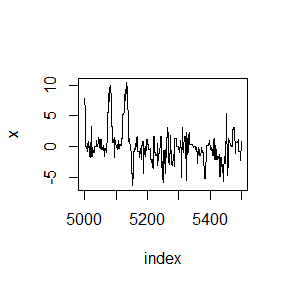

```r
set.seed(1)
m  <-  10000
sigma  <-2.7

x  <-  numeric(m)
x[1]  <-  rnorm(1,mean=0,sd=sigma)
#x[1]<-5
k  <-  0
u  <-  runif(m)
for  (i  in  2:m)  {
xt  <-  x[i-1]
y  <-  rnorm(1,mean=xt,sd=sigma)
num <- f(y) * dnorm(xt, mean=y,sd = sigma)
den <- f(xt) * dnorm(y,mean=xt ,sd=sigma)
if  (u[i]  <= num/den ) x[i]  <-  y  else  {

x[i]  <-  xt
k  <-  k+1         #y  is  rejected
}
}
index <- 5000:5500
y1 <- x[index]
plot(index, y1, type="l", main="", ylab="x")
```

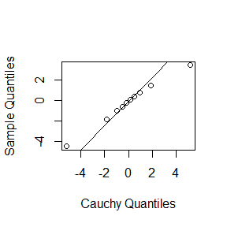

```r
###  compare the deciles of the generated observations
###  with the deciles of the standard Cauchy distribution
b <- 1001 #discard the burnin sample
y <- x[b:m]
a <- ppoints(10)
QR <- qt(a,df=1) #quantiles of Cauchy
Q <- quantile(x, a)
qqplot(QR, Q, main="",
xlab="Cauchy Quantiles", ylab="Sample Quantiles")
qqline(Q)
```

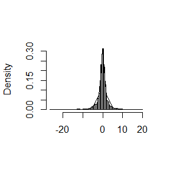

```r
hist(y, breaks="scott", main="", xlab="", freq=FALSE)
lines(QR, f(QR, theta = 1,eta=0))
```

#### Gelman-Rubin method

```r
Gelman.Rubin <- function(psi) {
# psi[i,j] is the statistic psi(X[i,1:j])
# for chain in i-th row of X
psi <- as.matrix(psi)
n <- ncol(psi)
k <- nrow(psi)
psi.means <- rowMeans(psi) #row means
B <- n * var(psi.means) #between variance est.
psi.w <- apply(psi, 1, "var") #within variances
W <- mean(psi.w) #within est.
v.hat <- W*(n-1)/n + (B/n) #upper variance est.
r.hat <- v.hat / W #G-R statistic
return(r.hat)
}
```

```r
cauchy.chain <- function(sigma, N, x1){
x  <-  numeric(N)
x[1]  <- x1
k  <-  0
u  <-  runif(N)
for  (i  in  2:N)  {
xt  <-  x[i-1]
y  <-  rnorm(1,mean=xt,sd=sigma)

num <- f(y) * dnorm(xt, mean=y,sd = sigma)
den <- f(xt) * dnorm(y,mean=xt ,sd=sigma)
if  (u[i]  <= num/den ) x[i]  <-  y  else  {
x[i]  <-  xt
k  <-  k+1         #y  is  rejected
}
}
return(x)
}
```

```r
set.seed(0)
sigma <- 0.2 #parameter of proposal distribution
k <- 4 #number of chains to generate
n <- 10000 #length of chains
b <- 1000 #burn-in length
#choose overdispersed initial values
x0 <- c(-1, -0.5, 0.5, 1)
#generate the chains
X <- matrix(0, nrow=k, ncol=n)
for (i in 1:k)
X[i, ] <- cauchy.chain(sigma, n, x0[i])
#compute diagnostic statistics
psi <- t(apply(X, 1, cumsum))
for (i in 1:nrow(psi))
psi[i,] <- psi[i,] / (1:ncol(psi))
print(Gelman.Rubin(psi))
```

```
## [1] 1.063909
```

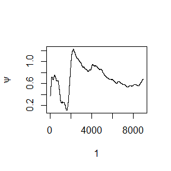

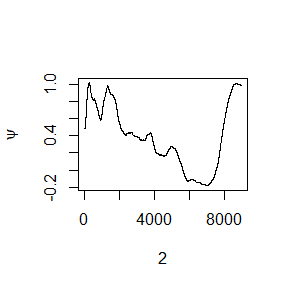

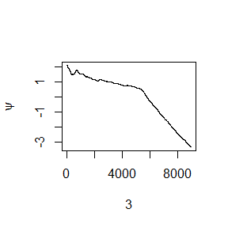

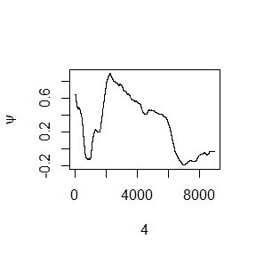

```r
#plot psi for the four chains
#par(mfrow=c(2,2))
for (i in 1:k)
plot(psi[i, (b+1):n], type="l",
xlab=i, ylab=bquote(psi))
```

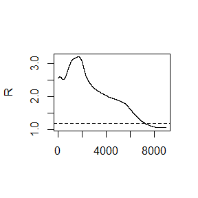

```r
#par(mfrow=c(1,1)) #restore default
#plot the sequence of R-hat statistics
rhat <- rep(0, n)
for (j in (b+1):n)
rhat[j] <- Gelman.Rubin(psi[,1:j])
plot(rhat[(b+1):n], type="l", xlab="", ylab="R")
abline(h=1.2, lty=2)
```

It shows that it converges approximately to the target distributioon according to $\hat{R}<1.2$.

### EXERCISE 9.8

This example appears in [40]. Consider the bivariate density
$$f (x, y) \propto \binom{n}{x}y^{x+a-1}(1 − y)^{n-x+b-1}, x = 0, 1,\cdots, n, 0 \leq y \leq 1.$$
It can be shown (see e.g. [23]) that for ﬁxed $a, b, n$, the conditional distributions are Binomial$(n, y)$ and Beta$(x + a, n - x + b)$. Use the Gibbs sampler to generate a chain with target joint density $f (x, y)$.

Use the Gelman-Rubin method to monitor convergence of chain, and run the chain until it converges approximately to the target distributioon according to $\hat{R}<1.2$.

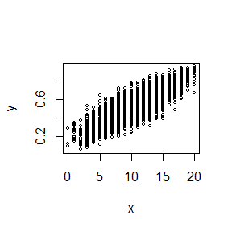

```r
set.seed(0)
N <- 5000 #length of chain
burn <- 1000 #burn-in length
X <- matrix(0, N, 2) #the chain, a bivariate sample
a=5
b=4
n=20
x=1;y=0.5
bichain<-function(N=5000,burn=1000,a=5,b=4,n=20,x=1,y=0.5,plot=FALSE){
  X <- matrix(0, N, 2)
  X[1, ] <- c(x,y) #initialize
for (i in 2:N) {
X[i, 1] <- rbinom(1,size=n,prob=y)
x<-X[i,1]
X[i, 2] <- rbeta(n=1,shape1 = x+a,shape2 = n-x+b)
y<-X[i,2]
}
b <- burn + 1
x <- X[b:N, ]
if(plot == TRUE)
plot(x, main="", cex=.5, xlab="x",
ylab="y", ylim=range(x[,2]))
else
return(X)
}
bichain(plot=TRUE)
```

#### Gelman-Rubin method

```r
library(R2OpenBUGS)
library(MCMCglmm)
```

[figure not shown]

```r
DATA1<- mcmc(data=cbind(bichain(x = 1,y=0.2,a=10,N=5000)))
DATA2<- mcmc(data=cbind(bichain(x= 10,y=0.8,a=10,N=5000)))

gelman.plot(x=c(mcmc.list(DATA1),mcmc.list(DATA2)))
```

### EXERCISE 11.3

1. Write a function to compute the $k^{th}$ term in
   $$\sum_{k=0}^{\infty}\frac{(-1)^k}{k!2^k}\frac{||a||^{2k+2}}{(2k+1)(2k+2)}\frac{\Gamma(\frac{d+1}{2})\Gamma(k+\frac{3}{2})}{\Gamma(k+\frac{d}{2}+1)},$$
   where $d\geq 1$ is an integer, $a$ is a vector in $\mathbb{R}^d$, and $||\cdot||$ denotes the Euclidean norm. Perform the arithmetic so that the coefficients can be computed for (almost) arbitrarily large k and d. (This sum converges for all $a\in\mathbb{R}^d$).
2. Modify the function so that it computes and returns the sum.
3. Evaluate the sum when $a = (1, 2)^T .$

```r
ft<-function(a,n=1e7,eps=1e-9,plot="TRUE")
{ ## 输入参数：
  ## a为d维实值向量
  ## n为最大迭代次数,默认取1e7
  ## eps为精度,默认取1e-9

  stopifnot(is.vector(a)) #当a不为向量时报错
  d<-length(a)            #d为a的维度

  an<-sqrt(sum(a^2))      #当a的模长为0时,输出0

  if(an==0) return ((list(res=0,k=0)))
  else{
    ## 注意到k!=gamma(k-1),k>=2时成立
    ## k=0,1时,k!=1,故将k=0,1情形单独列出
     for(k in 0:1){
    temp1<-(2*k+2)*log(an)+lgamma((d+1)/2)+lgamma(k+3/2)
    temp2<-k*log(2)+log(2*k+1)+log(2*k+2)+lgamma(k+d/2+1)
    temp<-exp(temp1-temp2)
    if(temp<=eps) {

      return(list(res=temp,k=k))
      }
    }

    for(k in 2:n){
    temp1<-(2*k+2)*log(an)+lgamma((d+1)/2)+lgamma(k+3/2)
    temp2<-lgamma(k-1)+k*log(2)+log(2*k+1)+log(2*k+2)+lgamma(k+d/2+1)
    temp<-exp(temp1-temp2)
    if(temp<=eps) {
      if(plot=="TRUE")
     { cat(c("d=",d,"\n"))
      cat(c("the Euclidean norm of a=",sqrt(sum(a^2)),"\n"))
      cat(c("k=",k,"\n"))
      cat("converge\n")}
      return(list(res=temp,k=k))
      }

    }
    #for循环正常结束,次数说明迭代次数较少,可能需要增加n的初始值
    cat("did not converge\n")
    return(list(res=temp,k=k))
  }

}
```

考虑极限情形，此时$\max{a_{(i)}}<=3,$,欧式模长未发散的情形下的最大维度$d$,与迭代次数$k$ 分别取
$$\begin{aligned}
a_1&\in \mathbb{R}^{d_1},d_1=2\times10^6\\
a_2&\in \mathbb{R}^{d_2},d_1=3\times10^6\\
\end{aligned}$$

```r
ff<-function(a,n=1e5,eps=1e-9)
{
  stopifnot(is.vector(a))
  d<-length(a)
  res<-0
  an<-sqrt(sum(a^2))
  if(an==0) return (0)
  else{
     for(k in 0:1){
    temp1<-(2*k+2)*log(an)+lgamma((d+1)/2)+lgamma(k+3/2)
    temp2<-k*log(2)+log(2*k+1)+log(2*k+2)+lgamma(k+d/2+1)
    temp<-exp(temp1-temp2)
    res<-res+(-1)^k*temp
    if(temp<=eps) {
      cat(c("k=",k,"\n"))
      cat("converge\n")
      return(res)
      }
    }

    for(k in 2:n){
    temp1<-(2*k+2)*log(an)+lgamma((d+1)/2)+lgamma(k+3/2)
    temp2<-lgamma(k-1)+k*log(2)+log(2*k+1)+log(2*k+2)+lgamma(k+d/2+1)
    temp<-exp(temp1-temp2)
    res<-res+(-1)^k*temp
    if(temp<=eps) {
      cat(c("k=",k,"\n"))
      cat("converge\n")
      return(res)
      }

    }
    cat("did not converge\n")
    return(res)
  }

}
```

```r
a<-seq(0,4,.01)
ff(a)
```

```
## k= 2141
## converge
```

```
## [1] -1.107445e+224
```

```r
a<-c(1,2)
ff(a)
```

```
## k= 18
## converge
```

```
## [1] 1.530156
```

#### Exercise 11.4

```r
SS<-function(a,k){
  stopifnot(k>1)
  n<-length(a)
  res<-numeric(n)
  for(i in 1:n){
     if(abs(a[i]^2-k-1)<1e-7) res[i]<-0
      else{
          temp<-sqrt(a[i]^2*k/(k+1-a[i]^2))
          res[i]<-(1-pt(temp,df=k))
  }
  }
 return(res)
}
```

以k=4,25,100为例，可以看出$S_k(x)-S_{k-1}(x)$是偶函数，因此，仅需要考虑$x<0$的情形

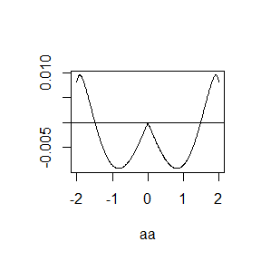

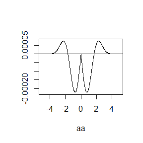

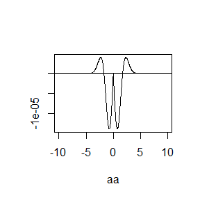

```r
for(k in c(4,25,100)){
  aa<-seq(-sqrt(k),sqrt(k),1e-2)
plot(aa,SS(aa,k)-SS(aa,k-1),ylab="",type="l")
abline(h=0)
}
```

```r
kk<-c(4:25,100,500,1000)
root<-matrix(0,nrow = length(kk),ncol = 3)
root[,1]<-kk
colnames(root)<-c("k","root_negative","root_positive")
for(i in  1: length(kk)){
  dsa<-function(a){
  return(SS(a,kk[i])-SS(a,kk[i]-1))
}
a<-seq(-sqrt(kk[i]),0,1e-3)
d1<-which.max(dsa(a))
d2<-which.min(dsa(a))
res<-uniroot(dsa, sort(a[c(d1,d2)]))
root[i,2]=unlist(res[1])
root[i,3]<-abs(root[i,2])
}
```

| k | root_negative | root_positive |
| --- | --- | --- |
| 4 | -1.492103 | 1.492103 |
| 5 | -1.533559 | 1.533559 |
| 6 | -1.562745 | 1.562745 |
| 7 | -1.584431 | 1.584431 |
| 8 | -1.601203 | 1.601203 |
| 9 | -1.614516 | 1.614516 |
| 10 | -1.625383 | 1.625383 |
| 11 | -1.634414 | 1.634414 |
| 12 | -1.642036 | 1.642036 |
| 13 | -1.648556 | 1.648556 |
| 14 | -1.654198 | 1.654198 |
| 15 | -1.659068 | 1.659068 |
| 16 | -1.663414 | 1.663414 |
| 17 | -1.667274 | 1.667274 |
| 18 | -1.670724 | 1.670724 |
| 19 | -1.673817 | 1.673817 |
| 20 | -1.676614 | 1.676614 |
| 21 | -1.679154 | 1.679154 |
| 22 | -1.681472 | 1.681472 |
| 23 | -1.683594 | 1.683594 |
| 24 | -1.685546 | 1.685546 |
| 25 | -1.687347 | 1.687347 |
| 100 | -1.720604 | 1.720604 |
| 500 | -1.729753 | 1.729753 |
| 1000 | -1.730905 | 1.730905 |

### EXERCISE 11.5

Write a function to solve the equation
$$\begin{aligned}
&\frac{2\Gamma(\frac{k}{2})}{\sqrt{\pi(k-1)}\Gamma(\frac{k-1}{2})}\int_0^{c_{k-1}}(1+\frac{u^2}{k-1})^{-k/2}du\\
=&\frac{2\Gamma(\frac{k+1}{2})}{\sqrt{\pi k}\Gamma(\frac{k}{2})}\int_0^{c_k}(1+\frac{u^2}{k})^{-(k+1)/2}du
\end{aligned}$$
for a, where
$$c_k=\sqrt{\frac{a^2k}{k+1-a^2}}.$$

Compare the solutions with the points $A(k)$ in Exercise 11.4.

注意到，等式左边
$$\begin{aligned}
&\frac{2\Gamma(\frac{k}{2})}{\sqrt{\pi(k-1)}\Gamma(\frac{k-1}{2})}\int_0^{c_{k-1}}(1+\frac{u^2}{k-1})^{-k/2}du\\
=&\frac{\Gamma(\frac{k}{2})}{\sqrt{\pi(k-1)}\Gamma(\frac{k-1}{2})}\int_{-c_{k-1}}^{c_{k-1}}(1+\frac{u^2}{k-1})^{-k/2}du\\
=&P(-c_{k-1}\leq t(k-1)\leq c_{k-1})\\
=&1-2S_{k-1}(a)
\end{aligned}$$
类似地
$$\begin{aligned}
&\frac{2\Gamma(\frac{k+1}{2})}{\sqrt{\pi k}\Gamma(\frac{k}{2})}\int_0^{c_k}(1+\frac{u^2}{k})^{-(k+1)/2}du\\
=&P(-c_{k}\leq t(k)\leq c_{k})\\
=&1-2S_{k}(a)
\end{aligned}$$

即解
$$S_{k}(a)=S_{k-1}(a), \ a\in(0,\sqrt{k})$$
故请见EXERCISE 11.4

### Supplementary

Suppose $T_1,\cdots,T_n$ are $i.i.d.$ samples drawn from the exponential distribution with expectation $\lambda$. Those valuesgreater than τ are not observed due to right censorship, so that the observed values are $Y_i=T_iI(T_i\leq\tau)+\tau I(T_i>\tau),i=1,\cdots,n.$Suppose $= 1 $and the observed $Y_i$ values are as follows:

$$0.54, 0.48, 0.33, 0.43, 1.00, 1.00, 0.91, 1.00, 0.21, 0.85$$
Use the E-M algorithm to estimate $\lambda$, compare your result with the observed data MLE (note: $Y_i$ follows a mixture distribution).

记$E_i=I(T_i>\tau)$,则

$$E_i|\lambda\sim B(1,p),\quad p=P(T>1|\lambda)=1-F(1|\lambda)=e^{-\frac{1}{\lambda}} ,\quad i=1,\cdots,m$$
观测到的$E_i$数据为
$$(0,0,0,0,1,1,0,1,0,0)$$
记
$$\begin{aligned}
&K_i=T_i(1-E_i)\\
&M_i=T_iE_i
\end{aligned}$$
则
$$T_i=K_i+M_i$$

而
$$f(t|\lambda)=\frac{1}{\lambda}e^{-\frac{1}{\lambda}t}I(t>0)$$

似然函数为

$$f(\boldsymbol{k,m}|\lambda)\propto\lambda^{-n} e^{-\sum_{i=1}^nt_i/\lambda}=\lambda^{-n} e^{-\sum_{i=1}^n(k_i+m_i)/\lambda}$$

E-M算法中的E步为
$$Q(\lambda,\hat{\lambda}^{(i)})=-n\ln \lambda-(\sum_{i=1}^nk_i)/\lambda- E(\sum_{j=1}^nm_j|\boldsymbol{E},\hat{\lambda}^{(i)})/\lambda$$
其中$m_j|E_j,\hat{\lambda}^{(i)}$的密度函数为

$$f_{m_j}(m|E_j,\hat{\theta}^{(i)})=1/\hat{\lambda}^{(i)}e^{-1/\hat{\lambda}^{(i)}m}(E_jI(m>1))/p$$

故均值为
$$E^*_j(\hat{\lambda}^{(i)}):=E(m_j|E_j,\hat{\lambda}^{(i)})=E_j(1+\hat{\lambda}^{(i)})e^{-1/\hat{\lambda}^{(i)}}/p=E_j(1+\hat{\lambda}^{(i)})$$

$$Q(\lambda,\hat{\lambda}^{(i)})=-n\ln \lambda-\sum_{i=1}^nk_i/\lambda- \sum_{j=1}^nE^*_j(\hat{\lambda}^{(i)})/\lambda$$

从而
$$\hat{\lambda}^{(i+1)}=\frac{\sum_{i=1}^nk_i+\sum_{j=1}^nE^*_j(\hat{\lambda}^{(i)})}{n}$$

```r
da<-c(0.54, 0.48, 0.33, 0.43, 1.00, 1.00, 0.91, 1.00, 0.21, 0.85)
k<-ifelse(da<1,da,0)
n<-length(da)
n_e<-n-sum(da<1)

estar<-function(lambda){
 return(n_e*(1+lambda))
}
EM<-function(k,n,max.it=1e4,eps=1e-7)
{


  i<-1
  lambda1<-5
  lambda2<-2

  while(abs(lambda1-lambda2)>=eps){
    lambda1<-lambda2
    lambda2<-(sum(k)+estar(lambda=lambda2))/(n)
    print(round(c(lambda2),5))
    if(i == max.it) break
    i<i+1
  }
  return(lambda2)
}
EM(k=k,n=n)
```

```
## [1] 1.275
## [1] 1.0575
## [1] 0.99225
## [1] 0.97267
## [1] 0.9668
## [1] 0.96504
## [1] 0.96451
## [1] 0.96435
## [1] 0.96431
## [1] 0.96429
## [1] 0.96429
## [1] 0.96429
## [1] 0.96429
## [1] 0.96429
## [1] 0.96429
```

```
## [1] 0.9642857
```

考虑$Y_i$的分布函数

$$\begin{aligned}
P(Y_i\leq x)=&P(Y_i\leq x|E_i=1)P(E_i=1)+P(Y_i\leq x|E_i=0)P(E_i=0)\\
=&P(1\leq x)p+P(T_i\leq x|T_i\leq 1)(1-p)\\
=&I(x\geq 1)p+[\frac{1-e^{-x/\lambda}}{1-e^{-1/\lambda}}I(x<1)+I(x\geq1)](1-p)\\
=&I(x\geq 1)+(1-e^{-x/\lambda})I(x<1)
\end{aligned}$$

似然函数
$$L(\lambda)=(\Pi_{i=1,E_i=1}^np)\times\Pi_{i=1,E_i=0}^n(e^{-y_i/\lambda}/\lambda)$$
对数似然函数
$$l(\lambda)=\sum_{i=1,E_i=1}^n-1/\lambda+\sum_{i=1,E_i=0}^n(-ln\lambda-y_i/\lambda)$$

解得MLE为
$$\lambda=\frac{\sum_{i=1,E_i=1}^n 1+\sum_{i=1,E_i=0}^ny_i}{\sum_{i=1}^n (1-E_i)}$$

```r
(n_e+sum(k))/(n-n_e)
```

```
## [1] 0.9642857
```

### 11.1.2 Exercises 1

1. Why are the following two invocations of lapply() equivalent?

```r
set.seed(0)
trims <- c(0, 0.1, 0.2, 0.5)
x <- rcauchy(100)
lapply(trims, function(trim) mean(x, trim = trim))
```

```
## [[1]]
## [1] 2.614189
##
## [[2]]
## [1] 0.3893497
##
## [[3]]
## [1] 0.2359156
##
## [[4]]
## [1] 0.1303608
```

```r
lapply(trims, mean, x = x)
```

```
## [[1]]
## [1] 2.614189
##
## [[2]]
## [1] 0.3893497
##
## [[3]]
## [1] 0.2359156
##
## [[4]]
## [1] 0.1303608
```

解:lapply的输入参数分别是X(一个list),FUN(一个函数),…(其他传入FUN的参数)

lapply的功能是将X的每一项传入FUN,输出一个新list

本题中输入参数均为trims

lapply的第一项调用内，函数项为固定mean函数中的参数x=x,根据trim输出对应的函数值

lapply的第二项调用内，函数项为mean函数,…中的参数x=x,传入mean中,故与第一项调用完全一致，输出相同

### 11.1.2 Exercises 5

5. For each model in the previous two exercises, extract $R^2$ using the function below.

```r
rsq <- function(mod) summary(mod)$r.squared
```

#### Exercises 3

```r
formulas <- list(
mpg ~ disp,
mpg ~ I(1 / disp),
mpg ~ disp + wt,
mpg ~ I(1 / disp) + wt
)

mod<-lapply(formulas, lm,data=mtcars)
r2<-lapply(mod, rsq)
round(unlist(r2),3)
```

```
## [1] 0.718 0.860 0.781 0.884
```

得到$R^2=(0.718,0.860,0.781,0.884)$

#### Exercises 4

```r
bootstraps <- lapply(1:10, function(i) {
rows <- sample(1:nrow(mtcars), rep = TRUE)
mtcars[rows, ]
})
mod<-lapply(bootstraps, lm,formula=mpg ~ disp )
r2<-lapply(mod, rsq)
round(unlist(r2),3)
```

```
##  [1] 0.761 0.816 0.815 0.815 0.662 0.614 0.587 0.718 0.746 0.756
```

$R^2=(0.761,0.816,0.815,0.815,0.662,0.614,0.587,0.718,0.746,0.756)$

### 11.2.5 Exercises 1

1. Use vapply() to:
1. Compute the standard deviation of every column in a numeric data frame.
2. Compute the standard deviation of every numeric column in a mixed data frame. (Hint: you’ll need to use vapply() twice.)

#### a

```r
set.seed(0)
df<-data.frame(replicate(6,sample(c(1:10),10,rep=T)))
round(vapply(df, sd,FUN.VALUE = double(1)),3)
```

```
##    X1    X2    X3    X4    X5    X6
## 2.807 2.121 3.240 2.263 2.119 2.459
```

#### a

```r
set.seed(0)
df<-data.frame(replicate(6,sample(c(1:10),10,rep=T)),y=rep("a",10))

round(vapply(df[vapply(df, is.integer, FUN.VALUE = logical(1))]
             , sd,FUN.VALUE = double(1)),3)
```

```
##    X1    X2    X3    X4    X5    X6
## 2.807 2.121 3.240 2.263 2.119 2.459
```

### 11.2.5 Exercises 7

7. Implement mcsapply(), a multicore version of sapply(). Can you implement mcvapply(), a parallel version of vapply()? Why or why not?

```r
library(parallel)
nocore<-detectCores()-1
cl<-makeCluster(nocore)
```

```r
mcsapply<-function(cl=makeCluster(detectCores()-1),X,FUN){
  parallel::parLapply(cl, X, FUN)
}

mcsapply(cl, 1:4, function(x) x+3)
```

```
## [[1]]
## [1] 4
##
## [[2]]
## [1] 5
##
## [[3]]
## [1] 6
##
## [[4]]
## [1] 7
```

```r
mcvapply<-function(cl=makeCluster(detectCores()-1),X,FUN,USE.NAMES =TRUE){
 Y=X[sapply(X, function(x) typeof(x)==typeof(USE.NAMES))]
 if(length(Y)==0) return("ERROR")
 else(parLapply(cl, Y, FUN))

}
mcvapply(cl, 1:4, function(x) x+3,USE.NAMES = integer(1))
```

```
## [[1]]
## [1] 4
##
## [[2]]
## [1] 5
##
## [[3]]
## [1] 6
##
## [[4]]
## [1] 7
```

```r
mcvapply(cl, 1:4, function(x) x+3,USE.NAMES = TRUE)
```

```
## [1] "ERROR"
```

## HW10

### Write an Rcpp function for Exercise 9.8

This example appears in [40]. Consider the bivariate density
$$f(x,y)\propto \binom{n}{x}y^{x+a-1}(1-y)^{n-x+b-1},\quad x=0,1,\cdots,n,0\leq y \leq 1.$$
It can be shown (see e.g. [23]) that for fixed $a, b, n$, the conditional distributions are $Binomial(n, y)$ and $Beta(x+ a, n − x+ b)$. Use the Gibbs sampler to generate a chain with target joint density $f(x, y).$

```r
set.seed(0)
#library(Rcpp)
Rcpp::cppFunction(
'NumericMatrix gibbsC(int N) {
  NumericMatrix mat(N, 2);
  double x = 0, y = 0, a=5,b=4,n=20;
  for(int i = 0; i < N; i++) {

      x = rbinom(1,n,y)[0];
      y = rbeta(1,x+a,n-x+b)[0];

    mat(i, 0) = x;
    mat(i, 1) = y;
  }
  return(mat);
}'
)
```

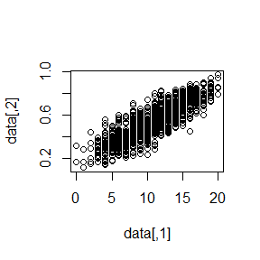

```r
data<-gibbsC(1000)
plot(data)
```

### Supplement

- Compare the corresponding generated random numbers with pure R language using the function “qqplot”

```r
Rcpp::cppFunction('NumericVector cunif(int n,double min,double max){
            NumericVector x;
            x=runif(n,min,max);
            return(x);
            }')
```

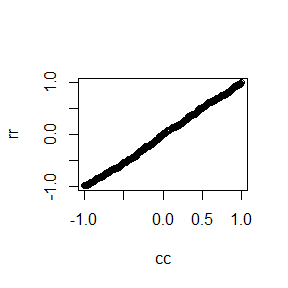

```r
set.seed(0)
cc<-cunif(n=1000,min=-1,max=1)
rr<-runif(n=1000,min=-1,max=1)
qqplot(cc,rr)
```

- Campare the computation time of the two functions with the function “microbenchmark”.

```r
 #   library(microbenchmark)
ts <- microbenchmark::microbenchmark(cc<-cunif(n=1000,min=-1,max=1),
rr<-runif(n=1000,min=-1,max=1))
    summary(ts)[,c(1,3,5,6)]
```

```
##                                       expr   lq median    uq
## 1 cc <- cunif(n = 1000, min = -1, max = 1)  9.4    9.8 10.15
## 2 rr <- runif(n = 1000, min = -1, max = 1) 33.9   34.4 34.75
```

- Comments your results.

可以看出使用cpp函数所用时间远小于使用r原生函数，且两方法结果上看一致。